# examples_0402

Compare candidates X and Z.

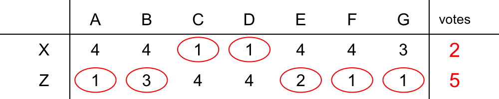

So, Z beats X.

Compare candidates Y and Z.

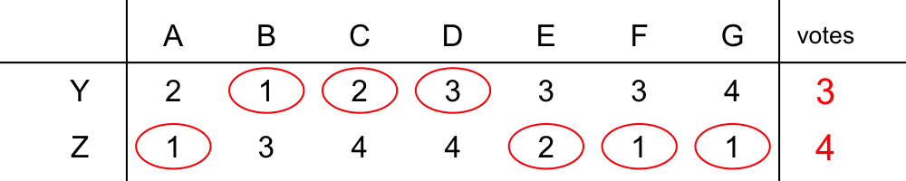

So, Z beats Y.

Organize all this into a winner table.

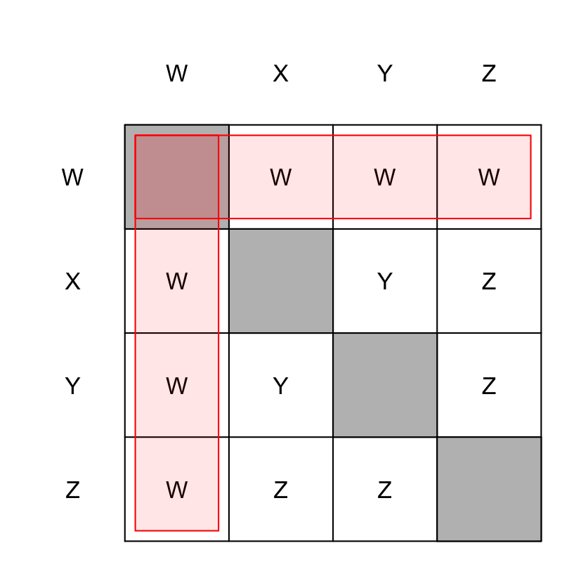

Notice W wins against all other candidates. Thus W is the Condorcet winner.

In Adams, Massachusetts, 4 candidates (W through Z) are running in an election with a single winner. There are 7 voters (A through G) who each rank the candidates from 1 to 4, with 1 meaning first choice and 4 meaning last choice. Those rankings are shown below. Each column represents a single voter's ranking.

|  | A | B | C | D | E | F | G |
| --- | --- | --- | --- | --- | --- | --- | --- |
| candidate W | 3 | 2 | 1 | 4 | 3 | 2 | 1 |
| candidate X | 4 | 4 | 2 | 3 | 1 | 1 | 3 |
| candidate Y | 2 | 1 | 3 | 1 | 4 | 3 | 2 |
| candidate Z | 1 | 3 | 4 | 2 | 2 | 4 | 4 |

A [Condorcet winner](https://en.wikipedia.org/wiki/Condorcet_method) would win in a head-to-head election against any other candidate. Who is the Condorcet winner? (Or, possibly, there is none.)

WXYZNo Condorcet winner!

Consider every head-to-head election. With 4 candidates, there will be ${4\choose 2 }= 6$ pairings (see [combinations](https://en.wikipedia.org/wiki/Binomial_coefficient)).

Compare candidates W and X.

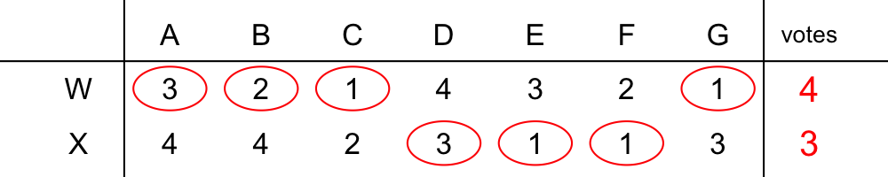

So, W beats X.

Compare candidates W and Y.

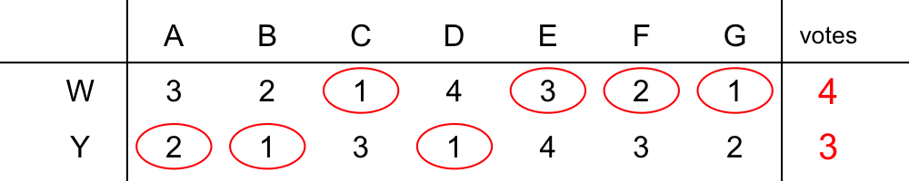

So, W beats Y.

Compare candidates W and Z.

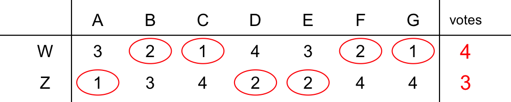

So, W beats Z.

Compare candidates X and Y.

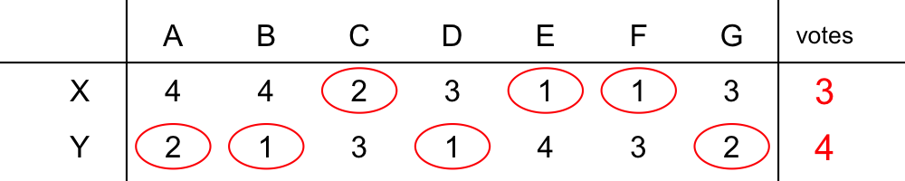

So, Y beats X.

Compare candidates X and Z.

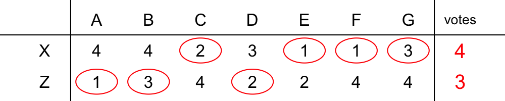

So, X beats Z.

Compare candidates Y and Z.

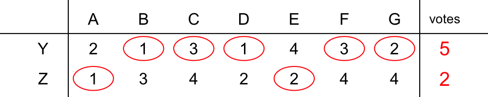

So, Y beats Z.

Organize all this into a winner table.

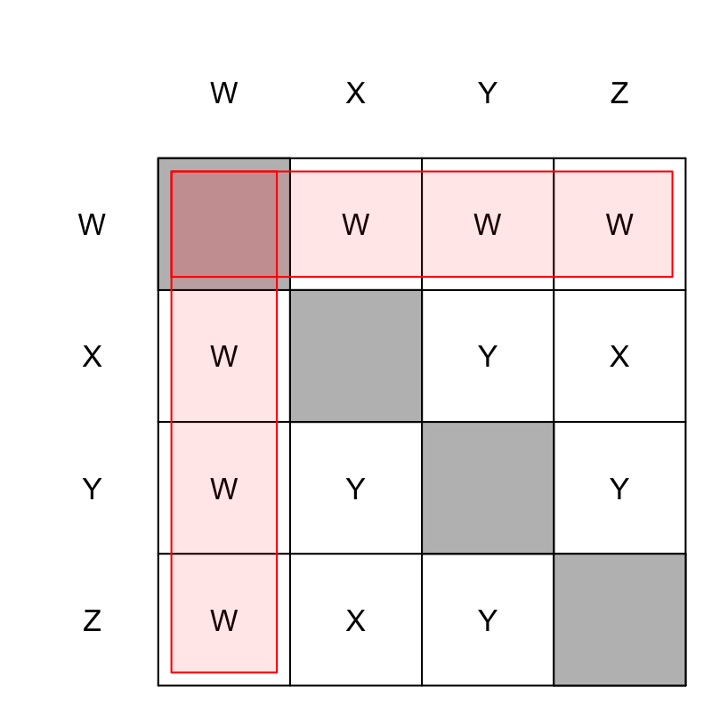

Notice W wins against all other candidates. Thus W is the Condorcet winner.

In Adams, Massachusetts, 4 candidates (W through Z) are running in an election with a single winner. There are 7 voters (A through G) who each rank the candidates from 1 to 4, with 1 meaning first choice and 4 meaning last choice. Those rankings are shown below. Each column represents a single voter's ranking.

|  | A | B | C | D | E | F | G |
| --- | --- | --- | --- | --- | --- | --- | --- |
| candidate W | 4 | 4 | 1 | 3 | 2 | 2 | 3 |
| candidate X | 1 | 2 | 4 | 4 | 1 | 3 | 1 |
| candidate Y | 2 | 1 | 2 | 2 | 4 | 1 | 4 |
| candidate Z | 3 | 3 | 3 | 1 | 3 | 4 | 2 |

A [Condorcet winner](https://en.wikipedia.org/wiki/Condorcet_method) would win in a head-to-head election against any other candidate. Who is the Condorcet winner? (Or, possibly, there is none.)

WXYZNo Condorcet winner!

Consider every head-to-head election. With 4 candidates, there will be ${4\choose 2 }= 6$ pairings (see [combinations](https://en.wikipedia.org/wiki/Binomial_coefficient)).

Compare candidates W and X.

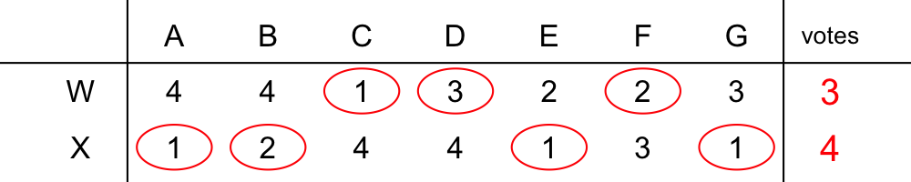

So, X beats W.

Compare candidates W and Y.

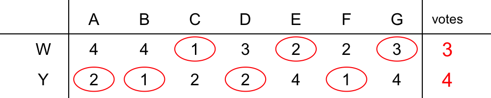

So, Y beats W.

Compare candidates W and Z.

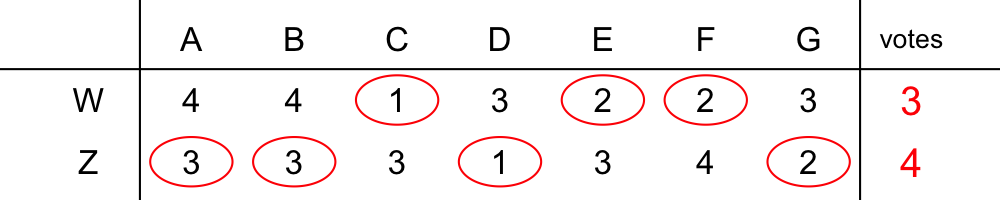

So, Z beats W.

Compare candidates X and Y.

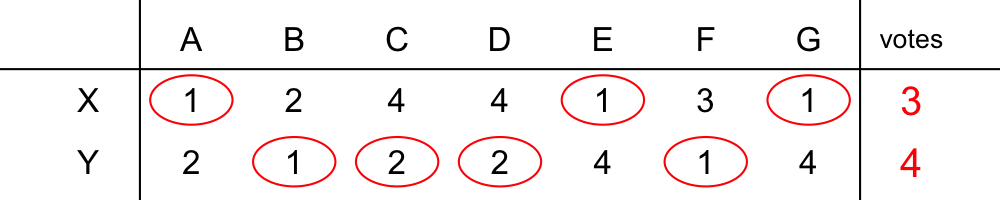

So, Y beats X.

Compare candidates X and Z.

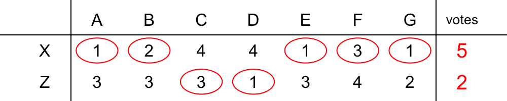

So, X beats Z.

Compare candidates Y and Z.

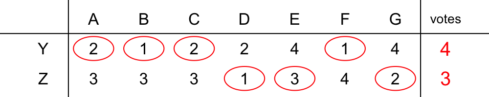

So, Y beats Z.

Organize all this into a winner table.

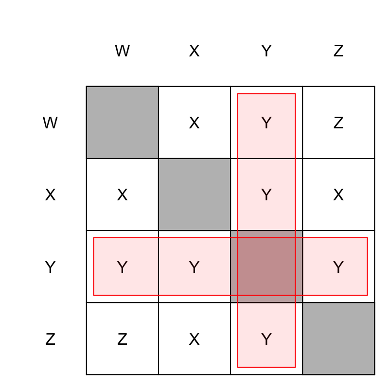

Notice Y wins against all other candidates. Thus Y is the Condorcet winner.

In Adams, Massachusetts, 4 candidates (W through Z) are running in an election with a single winner. There are 7 voters (A through G) who each rank the candidates from 1 to 4, with 1 meaning first choice and 4 meaning last choice. Those rankings are shown below. Each column represents a single voter's ranking.

|  | A | B | C | D | E | F | G |
| --- | --- | --- | --- | --- | --- | --- | --- |
| candidate W | 2 | 3 | 1 | 4 | 4 | 1 | 1 |
| candidate X | 4 | 1 | 2 | 2 | 1 | 4 | 4 |
| candidate Y | 3 | 4 | 4 | 3 | 3 | 2 | 2 |
| candidate Z | 1 | 2 | 3 | 1 | 2 | 3 | 3 |

A [Condorcet winner](https://en.wikipedia.org/wiki/Condorcet_method) would win in a head-to-head election against any other candidate. Who is the Condorcet winner? (Or, possibly, there is none.)

WXYZNo Condorcet winner!

Consider every head-to-head election. With 4 candidates, there will be ${4\choose 2 }= 6$ pairings (see [combinations](https://en.wikipedia.org/wiki/Binomial_coefficient)).

Compare candidates W and X.

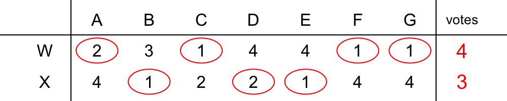

So, W beats X.

Compare candidates W and Y.

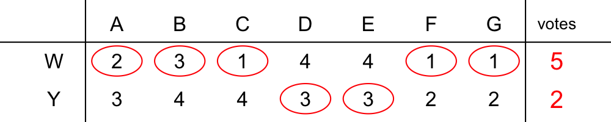

So, W beats Y.

Compare candidates W and Z.

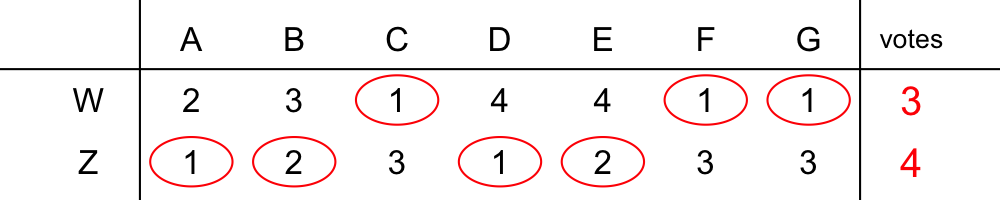

So, Z beats W.

Compare candidates X and Y.

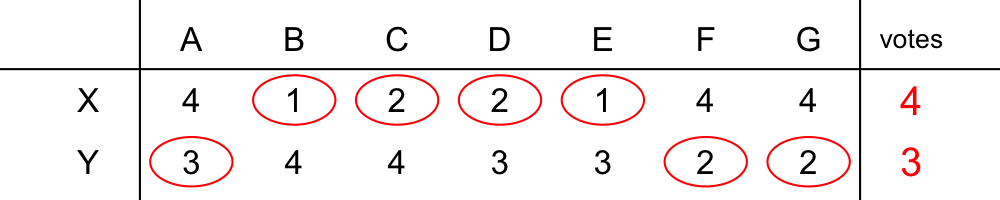

So, X beats Y.

Compare candidates X and Z.

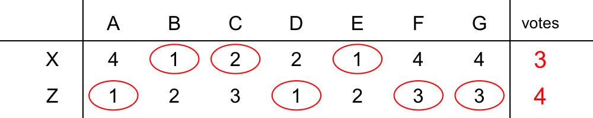

So, Z beats X.

Compare candidates Y and Z.

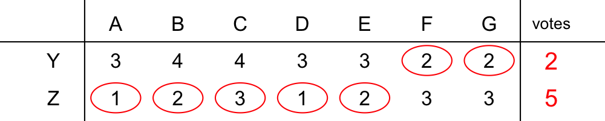

So, Z beats Y.

Organize all this into a winner table.

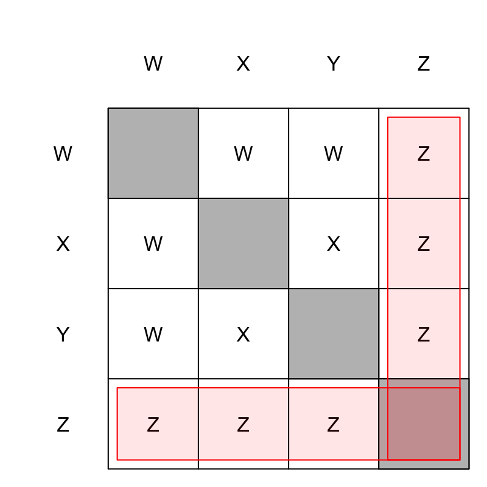

Notice Z wins against all other candidates. Thus Z is the Condorcet winner.

In Adams, Massachusetts, 4 candidates (W through Z) are running in an election with a single winner. There are 7 voters (A through G) who each rank the candidates from 1 to 4, with 1 meaning first choice and 4 meaning last choice. Those rankings are shown below. Each column represents a single voter's ranking.

|  | A | B | C | D | E | F | G |
| --- | --- | --- | --- | --- | --- | --- | --- |
| candidate W | 1 | 1 | 2 | 4 | 4 | 3 | 1 |
| candidate X | 3 | 2 | 4 | 2 | 1 | 1 | 4 |
| candidate Y | 4 | 3 | 1 | 1 | 2 | 2 | 2 |
| candidate Z | 2 | 4 | 3 | 3 | 3 | 4 | 3 |

A [Condorcet winner](https://en.wikipedia.org/wiki/Condorcet_method) would win in a head-to-head election against any other candidate. Who is the Condorcet winner? (Or, possibly, there is none.)

WXYZNo Condorcet winner!

Consider every head-to-head election. With 4 candidates, there will be ${4\choose 2 }= 6$ pairings (see [combinations](https://en.wikipedia.org/wiki/Binomial_coefficient)).

Compare candidates W and X.

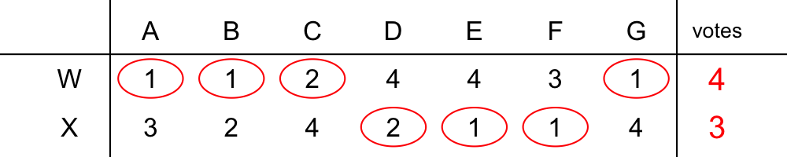

So, W beats X.

Compare candidates W and Y.

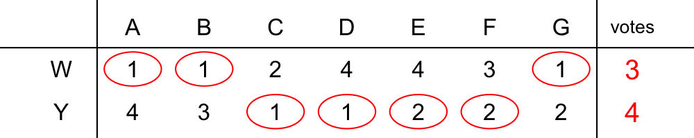

So, Y beats W.

Compare candidates W and Z.

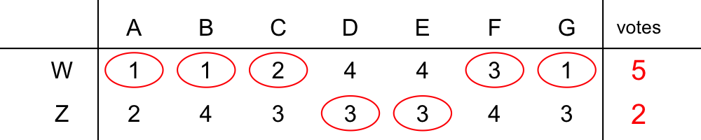

So, W beats Z.

Compare candidates X and Y.

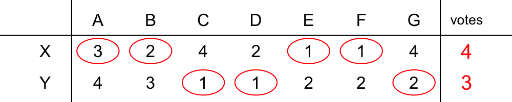

So, X beats Y.

Compare candidates X and Z.

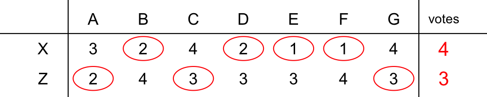

So, X beats Z.

Compare candidates Y and Z.

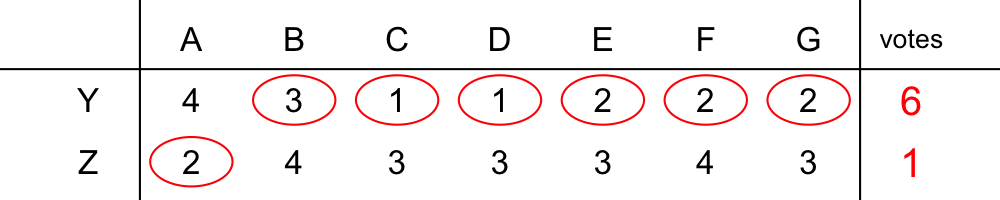

So, Y beats Z.

Organize all this into a winner table.

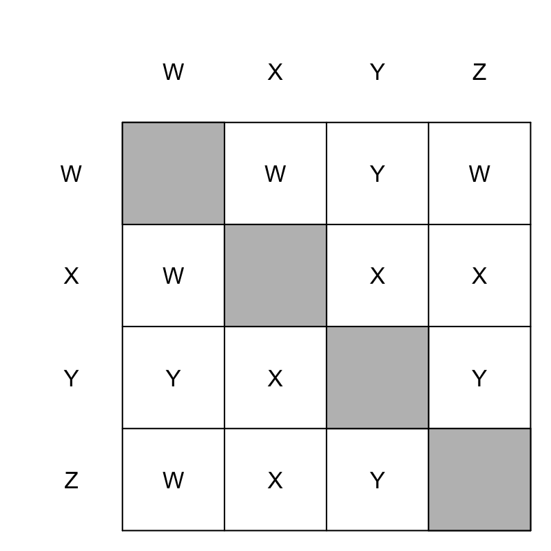

No candidate wins against every other candidate. There is no Condorcet winner.

In Adams, Massachusetts, 4 candidates (W through Z) are running in an election with a single winner. There are 7 voters (A through G) who each rank the candidates from 1 to 4, with 1 meaning first choice and 4 meaning last choice. Those rankings are shown below. Each column represents a single voter's ranking.

|  | A | B | C | D | E | F | G |
| --- | --- | --- | --- | --- | --- | --- | --- |
| candidate W | 2 | 2 | 1 | 3 | 3 | 1 | 2 |
| candidate X | 1 | 3 | 4 | 4 | 1 | 3 | 3 |
| candidate Y | 4 | 1 | 2 | 2 | 2 | 4 | 4 |
| candidate Z | 3 | 4 | 3 | 1 | 4 | 2 | 1 |

A [Condorcet winner](https://en.wikipedia.org/wiki/Condorcet_method) would win in a head-to-head election against any other candidate. Who is the Condorcet winner? (Or, possibly, there is none.)

WXYZNo Condorcet winner!

Consider every head-to-head election. With 4 candidates, there will be ${4\choose 2 }= 6$ pairings (see [combinations](https://en.wikipedia.org/wiki/Binomial_coefficient)).

Compare candidates W and X.

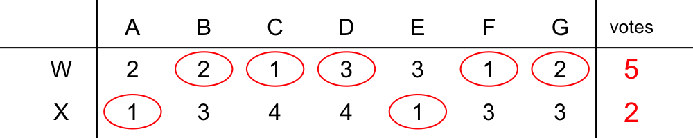

So, W beats X.

Compare candidates W and Y.

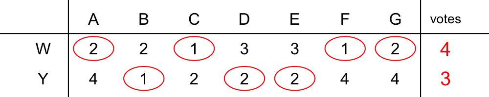

So, W beats Y.

Compare candidates W and Z.

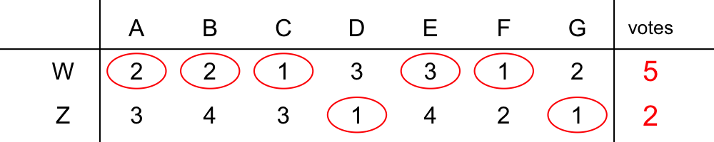

So, W beats Z.

Compare candidates X and Y.

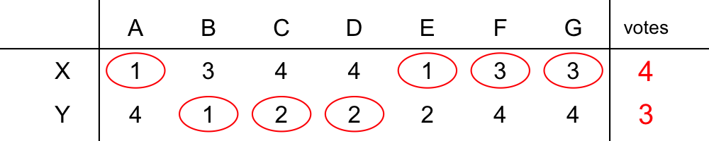

So, X beats Y.

Compare candidates X and Z.

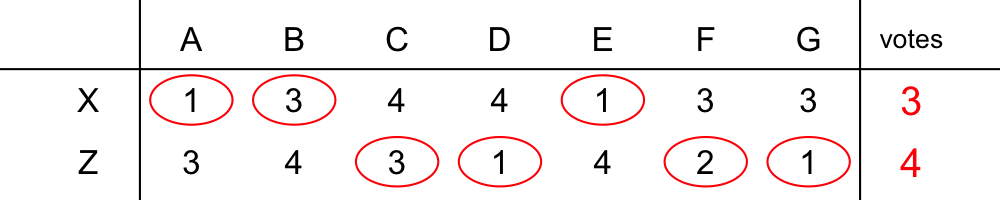

So, Z beats X.

Compare candidates Y and Z.

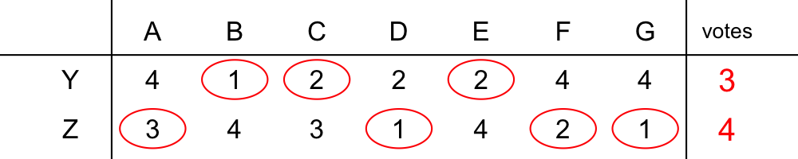

So, Z beats Y.

Organize all this into a winner table.

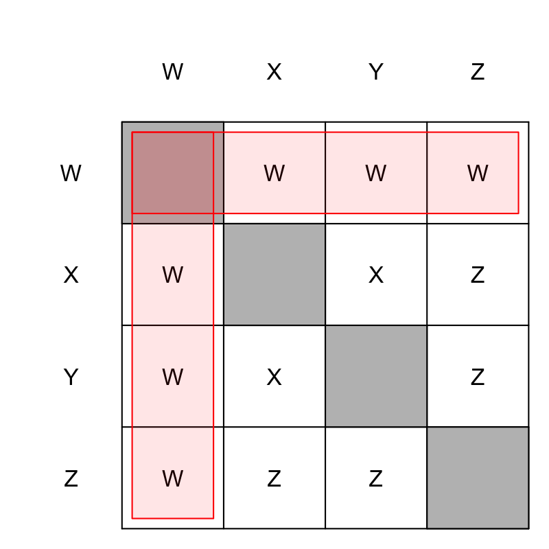

Notice W wins against all other candidates. Thus W is the Condorcet winner.

In Adams, Massachusetts, 4 candidates (W through Z) are running in an election with a single winner. There are 7 voters (A through G) who each rank the candidates from 1 to 4, with 1 meaning first choice and 4 meaning last choice. Those rankings are shown below. Each column represents a single voter's ranking.

|  | A | B | C | D | E | F | G |
| --- | --- | --- | --- | --- | --- | --- | --- |
| candidate W | 2 | 1 | 2 | 1 | 1 | 2 | 3 |
| candidate X | 4 | 3 | 4 | 3 | 3 | 3 | 2 |
| candidate Y | 3 | 2 | 3 | 2 | 2 | 4 | 1 |
| candidate Z | 1 | 4 | 1 | 4 | 4 | 1 | 4 |

A [Condorcet winner](https://en.wikipedia.org/wiki/Condorcet_method) would win in a head-to-head election against any other candidate. Who is the Condorcet winner? (Or, possibly, there is none.)

Consider every head-to-head election. With 4 candidates, there will be ${4\choose 2 }= 6$ pairings (see [combinations](https://en.wikipedia.org/wiki/Binomial_coefficient)).

Compare candidates W and X.

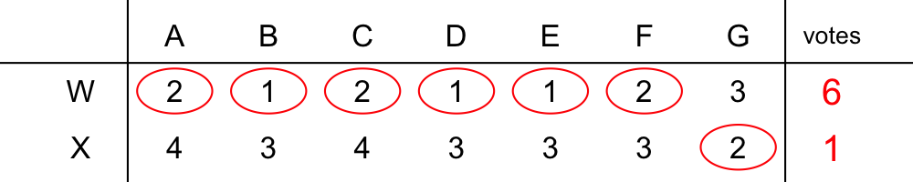

So, W beats X.

Compare candidates W and Y.

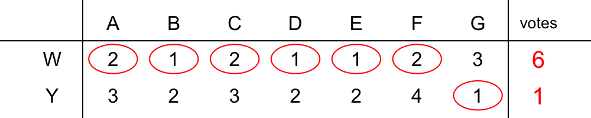

So, W beats Y.

Compare candidates W and Z.

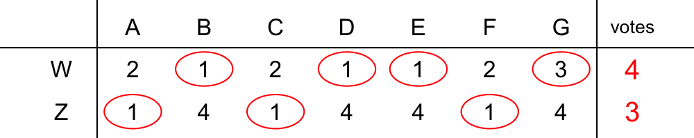

So, W beats Z.

Compare candidates X and Y.

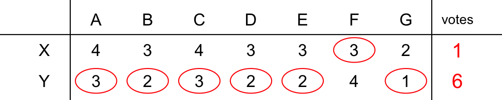

So, Y beats X.

Compare candidates X and Z.

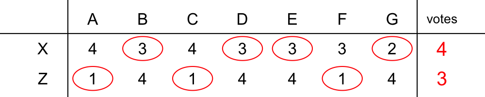

So, X beats Z.

Compare candidates Y and Z.

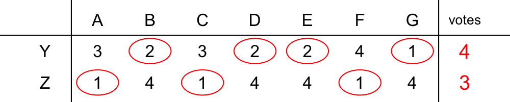

So, Y beats Z.

Organize all this into a winner table.

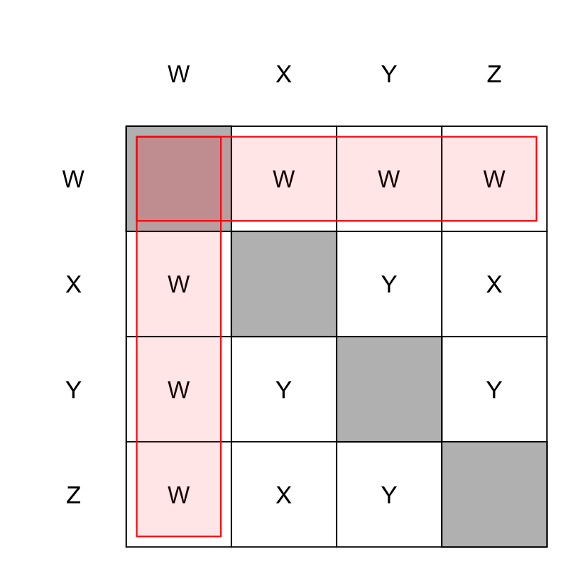

Notice W wins against all other candidates. Thus W is the Condorcet winner.

In Adams, Massachusetts, 4 candidates (W through Z) are running in an election with a single winner. There are 7 voters (A through G) who each rank the candidates from 1 to 4, with 1 meaning first choice and 4 meaning last choice. Those rankings are shown below. Each column represents a single voter's ranking.

|  | voter A | voter B | voter C | voter D | voter E | voter F | voter G |
| --- | --- | --- | --- | --- | --- | --- | --- |
| candidate W | 3 | 1 | 4 | 3 | 4 | 1 | 1 |
| candidate X | 4 | 3 | 3 | 1 | 3 | 3 | 4 |
| candidate Y | 2 | 4 | 2 | 2 | 1 | 2 | 3 |
| candidate Z | 1 | 2 | 1 | 4 | 2 | 4 | 2 |

A [Borda winner](https://en.wikipedia.org/wiki/Borda_count) is a candidate that gets the most Borda points, where each voter's ranking gives 0 points to the last choice, 1 point to the next lowest, etc.

How many Borda points would candidate W get from all 7 voters combined?

There are 4 candidates. So, we subtract each preference number from 4 to get Borda points. We then add all the Borda points from each voter.

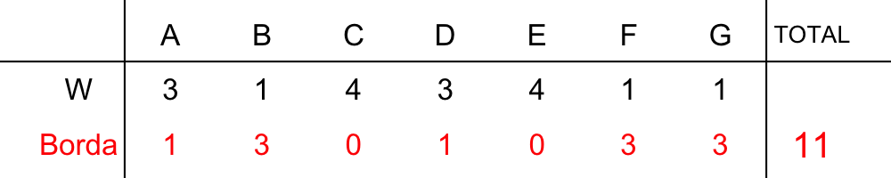

In Adams, Massachusetts, 3 candidates (X through Z) are running in an election with a single winner. There are 7 voters (A through G) who each rank the candidates from 1 to 3, with 1 meaning first choice and 3 meaning last choice. Those rankings are shown below. Each column represents a single voter's ranking.

|  | voter A | voter B | voter C | voter D | voter E | voter F | voter G |
| --- | --- | --- | --- | --- | --- | --- | --- |
| candidate X | 2 | 3 | 1 | 3 | 1 | 3 | 1 |
| candidate Y | 3 | 1 | 2 | 1 | 3 | 2 | 3 |
| candidate Z | 1 | 2 | 3 | 2 | 2 | 1 | 2 |

A [Borda winner](https://en.wikipedia.org/wiki/Borda_count) is a candidate that gets the most Borda points, where each voter's ranking gives 0 points to the last choice, 1 point to the next lowest, etc.

How many Borda points would candidate X get from all 7 voters combined?

There are 3 candidates. So, we subtract each preference number from 3 to get Borda points. We then add all the Borda points from each voter.

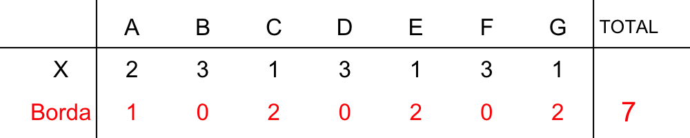

In Adams, Massachusetts, 5 candidates (V through Z) are running in an election with a single winner. There are 7 voters (A through G) who each rank the candidates from 1 to 5, with 1 meaning first choice and 5 meaning last choice. Those rankings are shown below. Each column represents a single voter's ranking.

|  | voter A | voter B | voter C | voter D | voter E | voter F | voter G |
| --- | --- | --- | --- | --- | --- | --- | --- |
| candidate V | 1 | 1 | 5 | 1 | 2 | 5 | 3 |
| candidate W | 4 | 2 | 4 | 3 | 4 | 2 | 4 |
| candidate X | 2 | 3 | 2 | 2 | 1 | 4 | 2 |
| candidate Y | 3 | 4 | 3 | 4 | 5 | 1 | 1 |
| candidate Z | 5 | 5 | 1 | 5 | 3 | 3 | 5 |

A [Borda winner](https://en.wikipedia.org/wiki/Borda_count) is a candidate that gets the most Borda points, where each voter's ranking gives 0 points to the last choice, 1 point to the next lowest, etc.

How many Borda points would candidate X get from all 7 voters combined?

There are 5 candidates. So, we subtract each preference number from 5 to get Borda points. We then add all the Borda points from each voter.

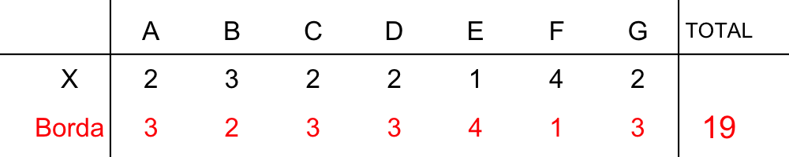

In Adams, Massachusetts, 5 candidates (V through Z) are running in an election with a single winner. There are 7 voters (A through G) who each rank the candidates from 1 to 5, with 1 meaning first choice and 5 meaning last choice. Those rankings are shown below. Each column represents a single voter's ranking.

|  | voter A | voter B | voter C | voter D | voter E | voter F | voter G |
| --- | --- | --- | --- | --- | --- | --- | --- |
| candidate V | 4 | 5 | 2 | 1 | 3 | 3 | 2 |
| candidate W | 2 | 3 | 1 | 2 | 5 | 1 | 3 |
| candidate X | 3 | 2 | 4 | 3 | 2 | 4 | 5 |
| candidate Y | 5 | 1 | 5 | 4 | 4 | 5 | 1 |
| candidate Z | 1 | 4 | 3 | 5 | 1 | 2 | 4 |

A [Borda winner](https://en.wikipedia.org/wiki/Borda_count) is a candidate that gets the most Borda points, where each voter's ranking gives 0 points to the last choice, 1 point to the next lowest, etc.

How many Borda points would candidate X get from all 7 voters combined?

There are 5 candidates. So, we subtract each preference number from 5 to get Borda points. We then add all the Borda points from each voter.

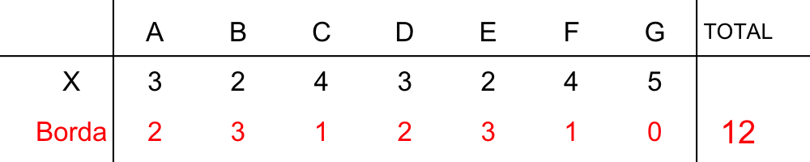

In Adams, Massachusetts, 3 candidates (X through Z) are running in an election with a single winner. There are 7 voters (A through G) who each rank the candidates from 1 to 3, with 1 meaning first choice and 3 meaning last choice. Those rankings are shown below. Each column represents a single voter's ranking.

|  | voter A | voter B | voter C | voter D | voter E | voter F | voter G |
| --- | --- | --- | --- | --- | --- | --- | --- |
| candidate X | 2 | 1 | 1 | 3 | 2 | 3 | 2 |
| candidate Y | 3 | 3 | 3 | 2 | 1 | 1 | 1 |
| candidate Z | 1 | 2 | 2 | 1 | 3 | 2 | 3 |

A [Borda winner](https://en.wikipedia.org/wiki/Borda_count) is a candidate that gets the most Borda points, where each voter's ranking gives 0 points to the last choice, 1 point to the next lowest, etc.

How many Borda points would candidate Z get from all 7 voters combined?

There are 3 candidates. So, we subtract each preference number from 3 to get Borda points. We then add all the Borda points from each voter.

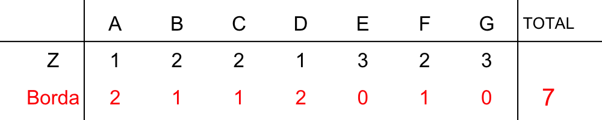

In Adams, Massachusetts, 4 candidates (W through Z) are running in an election with a single winner. There are 7 voters (A through G) who each rank the candidates from 1 to 4, with 1 meaning first choice and 4 meaning last choice. Those rankings are shown below. Each column represents a single voter's ranking.

|  | voter A | voter B | voter C | voter D | voter E | voter F | voter G |
| --- | --- | --- | --- | --- | --- | --- | --- |
| candidate W | 2 | 3 | 1 | 4 | 2 | 3 | 2 |
| candidate X | 3 | 2 | 4 | 2 | 4 | 1 | 1 |
| candidate Y | 4 | 4 | 2 | 3 | 1 | 2 | 4 |
| candidate Z | 1 | 1 | 3 | 1 | 3 | 4 | 3 |

A [Borda winner](https://en.wikipedia.org/wiki/Borda_count) is a candidate that gets the most Borda points, where each voter's ranking gives 0 points to the last choice, 1 point to the next lowest, etc.

How many Borda points would candidate Z get from all 7 voters combined?

There are 4 candidates. So, we subtract each preference number from 4 to get Borda points. We then add all the Borda points from each voter.

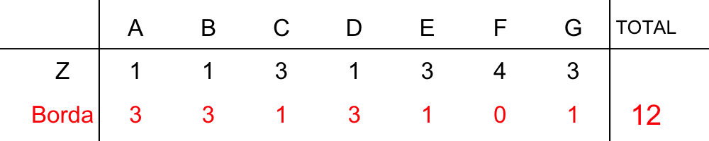

In Adams, Massachusetts, 5 candidates (V through Z) are running in an election with a single winner. There are 7 voters (A through G) who each rank the candidates from 1 to 5, with 1 meaning first choice and 5 meaning last choice. Those rankings are shown below. Each column represents a single voter's ranking.

|  | voter A | voter B | voter C | voter D | voter E | voter F | voter G |
| --- | --- | --- | --- | --- | --- | --- | --- |
| candidate V | 5 | 1 | 2 | 5 | 1 | 1 | 5 |
| candidate W | 4 | 2 | 3 | 4 | 4 | 4 | 1 |
| candidate X | 1 | 4 | 4 | 3 | 5 | 2 | 3 |
| candidate Y | 2 | 5 | 5 | 1 | 2 | 5 | 4 |
| candidate Z | 3 | 3 | 1 | 2 | 3 | 3 | 2 |

A [Borda winner](https://en.wikipedia.org/wiki/Borda_count) is a candidate that gets the most Borda points, where each voter's ranking gives 0 points to the last choice, 1 point to the next lowest, etc.

How many Borda points would candidate V get from all 7 voters combined?

There are 5 candidates. So, we subtract each preference number from 5 to get Borda points. We then add all the Borda points from each voter.

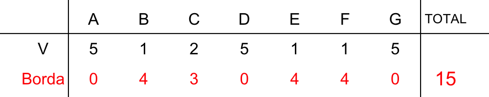

In Adams, Massachusetts, 6 candidates (U through Z) are running in an election with a single winner. There are 7 voters (A through G) who each rank the candidates from 1 to 6, with 1 meaning first choice and 6 meaning last choice. Those rankings are shown below. Each column represents a single voter's ranking.

|  | voter A | voter B | voter C | voter D | voter E | voter F | voter G |
| --- | --- | --- | --- | --- | --- | --- | --- |
| candidate U | 4 | 1 | 2 | 5 | 1 | 4 | 3 |
| candidate V | 6 | 5 | 4 | 1 | 5 | 6 | 1 |
| candidate W | 3 | 6 | 3 | 2 | 6 | 3 | 6 |
| candidate X | 2 | 4 | 5 | 3 | 4 | 2 | 4 |
| candidate Y | 5 | 3 | 1 | 6 | 3 | 5 | 2 |
| candidate Z | 1 | 2 | 6 | 4 | 2 | 1 | 5 |

A [Borda winner](https://en.wikipedia.org/wiki/Borda_count) is a candidate that gets the most Borda points, where each voter's ranking gives 0 points to the last choice, 1 point to the next lowest, etc.

How many Borda points would candidate U get from all 7 voters combined?

There are 6 candidates. So, we subtract each preference number from 6 to get Borda points. We then add all the Borda points from each voter.

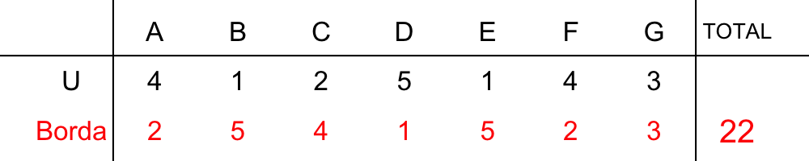

In Adams, Massachusetts, 6 candidates (U through Z) are running in an election with a single winner. There are 7 voters (A through G) who each rank the candidates from 1 to 6, with 1 meaning first choice and 6 meaning last choice. Those rankings are shown below. Each column represents a single voter's ranking.

|  | voter A | voter B | voter C | voter D | voter E | voter F | voter G |
| --- | --- | --- | --- | --- | --- | --- | --- |
| candidate U | 5 | 6 | 4 | 5 | 4 | 6 | 5 |
| candidate V | 6 | 2 | 2 | 4 | 1 | 2 | 1 |
| candidate W | 3 | 1 | 5 | 2 | 6 | 3 | 3 |
| candidate X | 4 | 4 | 6 | 3 | 5 | 1 | 4 |
| candidate Y | 2 | 3 | 3 | 6 | 2 | 4 | 2 |
| candidate Z | 1 | 5 | 1 | 1 | 3 | 5 | 6 |

A [Borda winner](https://en.wikipedia.org/wiki/Borda_count) is a candidate that gets the most Borda points, where each voter's ranking gives 0 points to the last choice, 1 point to the next lowest, etc.

How many Borda points would candidate Y get from all 7 voters combined?

There are 6 candidates. So, we subtract each preference number from 6 to get Borda points. We then add all the Borda points from each voter.

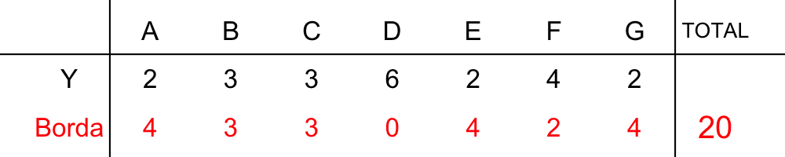

In Adams, Massachusetts, 4 candidates (W through Z) are running in an election with a single winner. There are 7 voters (A through G) who each rank the candidates from 1 to 4, with 1 meaning first choice and 4 meaning last choice. Those rankings are shown below. Each column represents a single voter's ranking.

|  | voter A | voter B | voter C | voter D | voter E | voter F | voter G |
| --- | --- | --- | --- | --- | --- | --- | --- |
| candidate W | 2 | 3 | 4 | 4 | 4 | 1 | 2 |
| candidate X | 3 | 1 | 2 | 1 | 2 | 2 | 3 |
| candidate Y | 4 | 2 | 1 | 2 | 3 | 4 | 1 |
| candidate Z | 1 | 4 | 3 | 3 | 1 | 3 | 4 |

A [Borda winner](https://en.wikipedia.org/wiki/Borda_count) is a candidate that gets the most Borda points, where each voter's ranking gives 0 points to the last choice, 1 point to the next lowest, etc.

How many Borda points would candidate Z get from all 7 voters combined?

There are 4 candidates. So, we subtract each preference number from 4 to get Borda points. We then add all the Borda points from each voter.

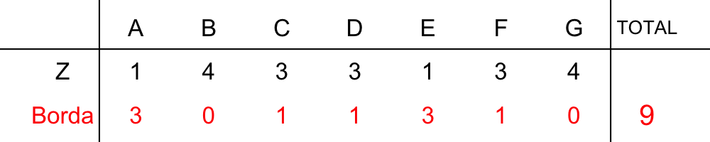

In Adams, Massachusetts, 5 candidates (V through Z) are running in an election with a single winner. There are 9 voters (A through I) who each rank the candidates from 1 to 5, with 1 meaning first choice and 5 meaning last choice. Those rankings are shown below. Each column represents a single voter's ranking.

|  | voter A | voter B | voter C | voter D | voter E | voter F | voter G | voter H | voter I |
| --- | --- | --- | --- | --- | --- | --- | --- | --- | --- |
| candidate V | 3 | 4 | 5 | 2 | 3 | 2 | 5 | 3 | 5 |
| candidate W | 1 | 1 | 3 | 1 | 4 | 5 | 2 | 5 | 1 |
| candidate X | 4 | 5 | 4 | 3 | 2 | 4 | 1 | 2 | 4 |
| candidate Y | 2 | 2 | 1 | 5 | 1 | 1 | 3 | 1 | 2 |
| candidate Z | 5 | 3 | 2 | 4 | 5 | 3 | 4 | 4 | 3 |

What [Borda count](https://en.wikipedia.org/wiki/Borda_count) would each candidate get?

- Borda count of candidate V:
- Borda count of candidate W:
- Borda count of candidate X:
- Borda count of candidate Y:
- Borda count of candidate Z:
- Who wins the Borda election?

There are 5 candidates. So, we subtract each preference number from 5 to get Borda points. We then add all the Borda points from each voter.

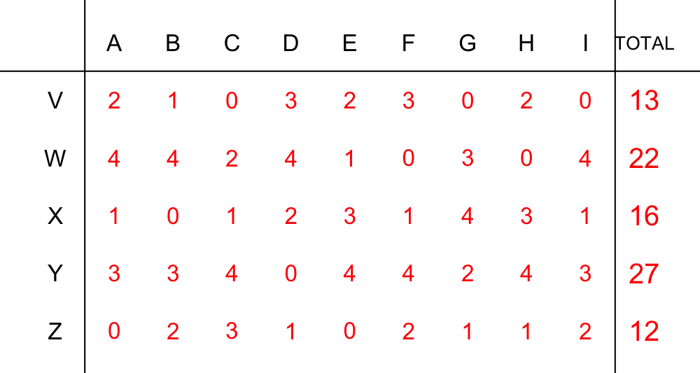

In Adams, Massachusetts, 4 candidates (W through Z) are running in an election with a single winner. There are 7 voters (A through G) who each rank the candidates from 1 to 4, with 1 meaning first choice and 4 meaning last choice. Those rankings are shown below. Each column represents a single voter's ranking.

|  | voter A | voter B | voter C | voter D | voter E | voter F | voter G |
| --- | --- | --- | --- | --- | --- | --- | --- |
| candidate W | 3 | 3 | 1 | 1 | 2 | 3 | 4 |
| candidate X | 4 | 2 | 3 | 3 | 4 | 2 | 1 |
| candidate Y | 1 | 4 | 2 | 2 | 1 | 4 | 2 |
| candidate Z | 2 | 1 | 4 | 4 | 3 | 1 | 3 |

What [Borda count](https://en.wikipedia.org/wiki/Borda_count) would each candidate get?

- Borda count of candidate W:
- Borda count of candidate X:
- Borda count of candidate Y:
- Borda count of candidate Z:
- Who wins the Borda election?

There are 4 candidates. So, we subtract each preference number from 4 to get Borda points. We then add all the Borda points from each voter.

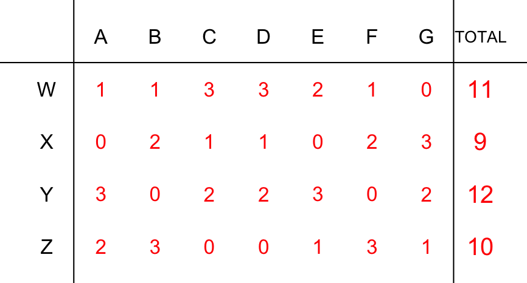

In Adams, Massachusetts, 4 candidates (W through Z) are running in an election with a single winner. There are 6 voters (A through F) who each rank the candidates from 1 to 4, with 1 meaning first choice and 4 meaning last choice. Those rankings are shown below. Each column represents a single voter's ranking.

|  | voter A | voter B | voter C | voter D | voter E | voter F |
| --- | --- | --- | --- | --- | --- | --- |
| candidate W | 1 | 1 | 2 | 2 | 1 | 4 |
| candidate X | 2 | 4 | 4 | 4 | 3 | 3 |
| candidate Y | 3 | 2 | 1 | 1 | 4 | 1 |
| candidate Z | 4 | 3 | 3 | 3 | 2 | 2 |

What [Borda count](https://en.wikipedia.org/wiki/Borda_count) would each candidate get?

- Borda count of candidate W:
- Borda count of candidate X:
- Borda count of candidate Y:
- Borda count of candidate Z:
- Who wins the Borda election?

There are 4 candidates. So, we subtract each preference number from 4 to get Borda points. We then add all the Borda points from each voter.

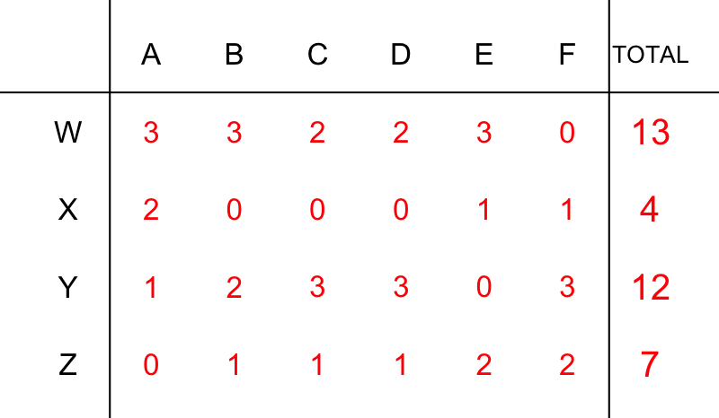

In Adams, Massachusetts, 5 candidates (V through Z) are running in an election with a single winner. There are 9 voters (A through I) who each rank the candidates from 1 to 5, with 1 meaning first choice and 5 meaning last choice. Those rankings are shown below. Each column represents a single voter's ranking.

|  | voter A | voter B | voter C | voter D | voter E | voter F | voter G | voter H | voter I |
| --- | --- | --- | --- | --- | --- | --- | --- | --- | --- |
| candidate V | 3 | 4 | 5 | 4 | 3 | 1 | 5 | 2 | 3 |
| candidate W | 4 | 5 | 4 | 3 | 4 | 3 | 1 | 5 | 4 |
| candidate X | 2 | 2 | 2 | 2 | 1 | 4 | 4 | 1 | 5 |
| candidate Y | 1 | 1 | 1 | 5 | 5 | 5 | 3 | 4 | 2 |
| candidate Z | 5 | 3 | 3 | 1 | 2 | 2 | 2 | 3 | 1 |

What [Borda count](https://en.wikipedia.org/wiki/Borda_count) would each candidate get?

- Borda count of candidate V:
- Borda count of candidate W:
- Borda count of candidate X:
- Borda count of candidate Y:
- Borda count of candidate Z:
- Who wins the Borda election?

There are 5 candidates. So, we subtract each preference number from 5 to get Borda points. We then add all the Borda points from each voter.

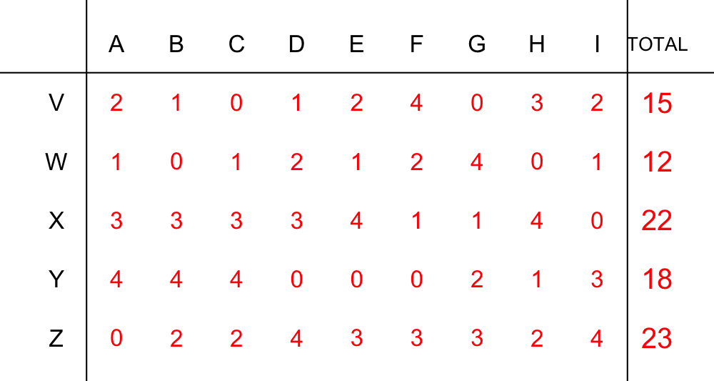

In Adams, Massachusetts, 4 candidates (W through Z) are running in an election with a single winner. There are 7 voters (A through G) who each rank the candidates from 1 to 4, with 1 meaning first choice and 4 meaning last choice. Those rankings are shown below. Each column represents a single voter's ranking.

|  | voter A | voter B | voter C | voter D | voter E | voter F | voter G |
| --- | --- | --- | --- | --- | --- | --- | --- |
| candidate W | 1 | 1 | 2 | 2 | 2 | 4 | 4 |
| candidate X | 4 | 2 | 4 | 1 | 3 | 3 | 2 |
| candidate Y | 2 | 4 | 1 | 4 | 1 | 2 | 3 |
| candidate Z | 3 | 3 | 3 | 3 | 4 | 1 | 1 |

What [Borda count](https://en.wikipedia.org/wiki/Borda_count) would each candidate get?

- Borda count of candidate W:
- Borda count of candidate X:
- Borda count of candidate Y:
- Borda count of candidate Z:
- Who wins the Borda election?

There are 4 candidates. So, we subtract each preference number from 4 to get Borda points. We then add all the Borda points from each voter.

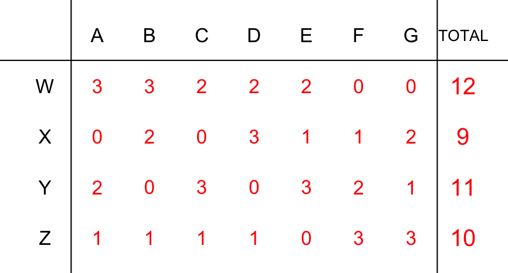

In Adams, Massachusetts, 4 candidates (W through Z) are running in an election with a single winner. There are 9 voters (A through I) who each rank the candidates from 1 to 4, with 1 meaning first choice and 4 meaning last choice. Those rankings are shown below. Each column represents a single voter's ranking.

|  | voter A | voter B | voter C | voter D | voter E | voter F | voter G | voter H | voter I |
| --- | --- | --- | --- | --- | --- | --- | --- | --- | --- |
| candidate W | 2 | 4 | 4 | 1 | 2 | 1 | 3 | 2 | 3 |
| candidate X | 1 | 2 | 1 | 2 | 3 | 2 | 2 | 3 | 4 |
| candidate Y | 4 | 1 | 3 | 4 | 4 | 4 | 1 | 1 | 1 |
| candidate Z | 3 | 3 | 2 | 3 | 1 | 3 | 4 | 4 | 2 |

What [Borda count](https://en.wikipedia.org/wiki/Borda_count) would each candidate get?

- Borda count of candidate W:
- Borda count of candidate X:
- Borda count of candidate Y:
- Borda count of candidate Z:
- Who wins the Borda election?

There are 4 candidates. So, we subtract each preference number from 4 to get Borda points. We then add all the Borda points from each voter.

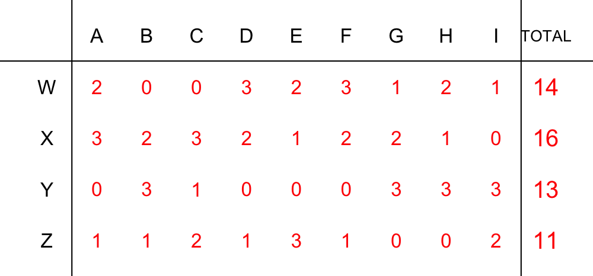

In Adams, Massachusetts, 4 candidates (W through Z) are running in an election with a single winner. There are 6 voters (A through F) who each rank the candidates from 1 to 4, with 1 meaning first choice and 4 meaning last choice. Those rankings are shown below. Each column represents a single voter's ranking.

|  | voter A | voter B | voter C | voter D | voter E | voter F |
| --- | --- | --- | --- | --- | --- | --- |
| candidate W | 3 | 1 | 3 | 3 | 2 | 4 |
| candidate X | 4 | 2 | 1 | 4 | 3 | 3 |
| candidate Y | 2 | 4 | 2 | 2 | 1 | 2 |
| candidate Z | 1 | 3 | 4 | 1 | 4 | 1 |

What [Borda count](https://en.wikipedia.org/wiki/Borda_count) would each candidate get?

- Borda count of candidate W:
- Borda count of candidate X:
- Borda count of candidate Y:
- Borda count of candidate Z:
- Who wins the Borda election?

There are 4 candidates. So, we subtract each preference number from 4 to get Borda points. We then add all the Borda points from each voter.

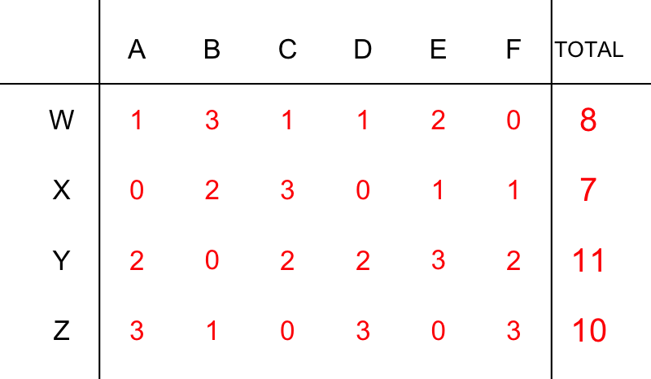

In Adams, Massachusetts, 5 candidates (V through Z) are running in an election with a single winner. There are 6 voters (A through F) who each rank the candidates from 1 to 5, with 1 meaning first choice and 5 meaning last choice. Those rankings are shown below. Each column represents a single voter's ranking.

|  | voter A | voter B | voter C | voter D | voter E | voter F |
| --- | --- | --- | --- | --- | --- | --- |
| candidate V | 1 | 2 | 3 | 4 | 2 | 3 |
| candidate W | 5 | 3 | 5 | 5 | 1 | 4 |
| candidate X | 3 | 1 | 1 | 1 | 5 | 5 |
| candidate Y | 2 | 5 | 4 | 2 | 3 | 1 |
| candidate Z | 4 | 4 | 2 | 3 | 4 | 2 |

What [Borda count](https://en.wikipedia.org/wiki/Borda_count) would each candidate get?

- Borda count of candidate V:
- Borda count of candidate W:
- Borda count of candidate X:
- Borda count of candidate Y:
- Borda count of candidate Z:
- Who wins the Borda election?

There are 5 candidates. So, we subtract each preference number from 5 to get Borda points. We then add all the Borda points from each voter.

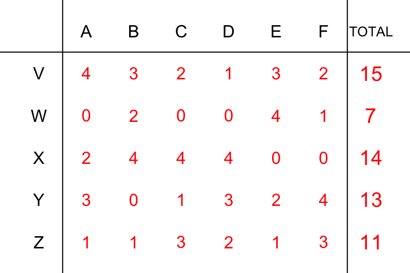

In Adams, Massachusetts, 5 candidates (V through Z) are running in an election with a single winner. There are 8 voters (A through H) who each rank the candidates from 1 to 5, with 1 meaning first choice and 5 meaning last choice. Those rankings are shown below. Each column represents a single voter's ranking.

|  | voter A | voter B | voter C | voter D | voter E | voter F | voter G | voter H |
| --- | --- | --- | --- | --- | --- | --- | --- | --- |
| candidate V | 1 | 3 | 2 | 1 | 2 | 3 | 4 | 4 |
| candidate W | 2 | 4 | 3 | 3 | 4 | 5 | 1 | 3 |
| candidate X | 4 | 2 | 1 | 5 | 5 | 2 | 2 | 2 |
| candidate Y | 5 | 1 | 4 | 4 | 1 | 4 | 5 | 5 |
| candidate Z | 3 | 5 | 5 | 2 | 3 | 1 | 3 | 1 |

What [Borda count](https://en.wikipedia.org/wiki/Borda_count) would each candidate get?

- Borda count of candidate V:
- Borda count of candidate W:
- Borda count of candidate X:
- Borda count of candidate Y:
- Borda count of candidate Z:
- Who wins the Borda election?

There are 5 candidates. So, we subtract each preference number from 5 to get Borda points. We then add all the Borda points from each voter.

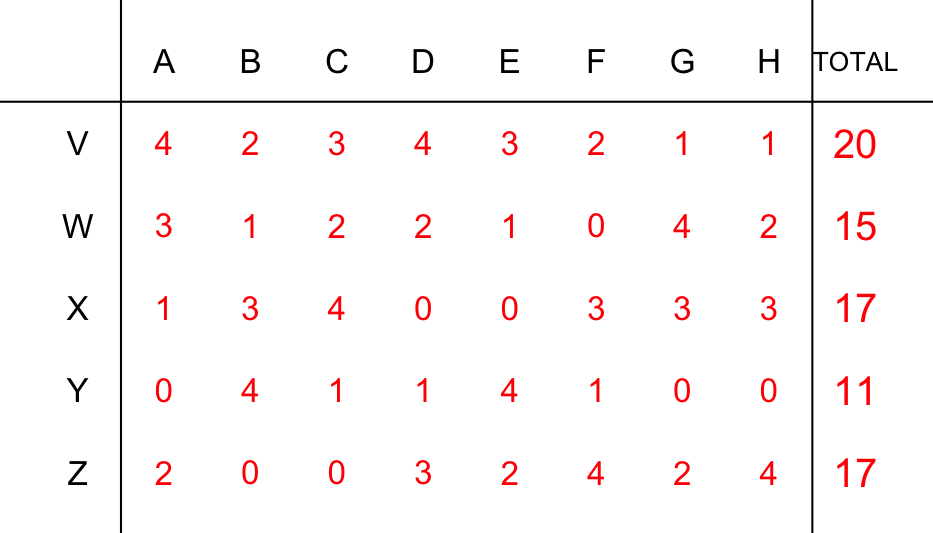

In Adams, Massachusetts, 4 candidates (W through Z) are running in an election with a single winner. There are 8 voters (A through H) who each rank the candidates from 1 to 4, with 1 meaning first choice and 4 meaning last choice. Those rankings are shown below. Each column represents a single voter's ranking.

|  | voter A | voter B | voter C | voter D | voter E | voter F | voter G | voter H |
| --- | --- | --- | --- | --- | --- | --- | --- | --- |
| candidate W | 3 | 3 | 3 | 2 | 4 | 1 | 1 | 3 |
| candidate X | 2 | 1 | 4 | 4 | 3 | 4 | 3 | 2 |
| candidate Y | 4 | 2 | 1 | 3 | 2 | 3 | 2 | 1 |
| candidate Z | 1 | 4 | 2 | 1 | 1 | 2 | 4 | 4 |

What [Borda count](https://en.wikipedia.org/wiki/Borda_count) would each candidate get?